# Activity Analysis

#### 4. Make a histogram of the total number of steps taken each day and Calculate and report the mean and median total number of steps taken per day.

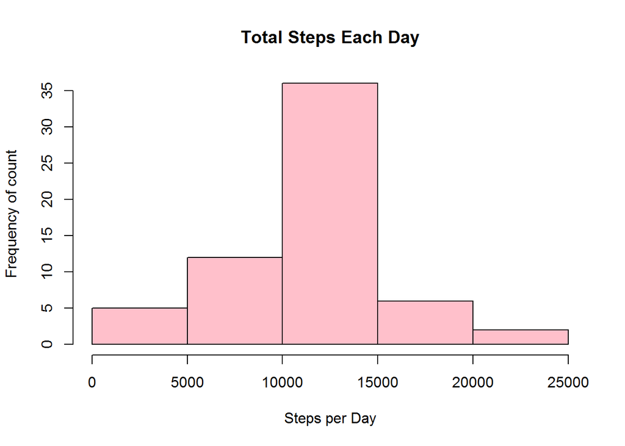

```r
StepsPerDayNew<- aggregate(steps ~ date, ActivityDataNew, sum)
hist(StepsPerDayNew$steps, main = c("Total Steps Each Day"), col="pink", xlab="Steps per Day",ylab="Frequency of count" )
```

```r
paste("Mean of the new dataset = ",mean(StepsPerDayNew$steps))
```

```
## [1] "Mean of the new dataset =  10766.1886792453"
```

```r
paste("Median of the new dataset = ",median(StepsPerDayNew$steps))
```

```
## [1] "Median of the new dataset =  10766.1886792453"
```

#### Do these values differ from the estimates from the first part of the assignment?

```r
paste(" Difference between the means = ",mean(StepsPerDay$steps)-mean(StepsPerDayNew$steps) )
```

```
## [1] " Difference between the means =  0"
```

```r
paste(" Difference between the medians = ",median(StepsPerDay$steps)-median(StepsPerDayNew$steps) )
```

```
## [1] " Difference between the medians =  -1.1886792452824"
```

#### What is the impact of imputing missing data on the estimates of the total daily number of steps?

#### There is no major impact on imputing missing data. The histograms are nearly equal. The means are same and there is small difference in median value

### Are there differences in activity patterns between weekdays and weekends?

#### Create a new factor variable in the dataset with two levels - “weekday” and “weekend” indicating whether a given date is a weekday or weekend day

```r
day <- weekdays(ActivityData$date)
daylevel <- vector()
for (i in 1:nrow(ActivityData))
{
    if ( (day[i] == "Saturday") || (day[i] == "Sunday"))
    {
        daylevel[i] <- "Weekend"
    } else {

          daylevel[i] <- "Weekday"
            }
}
ActivityData$daylevel <- daylevel
ActivityData$daylevel <- factor(ActivityData$daylevel)
```

#### Created a plot to compare and contrast number of steps between the week and weekend.

#### There is a higher peak earlier on weekdays and higher overall activity during weekends.

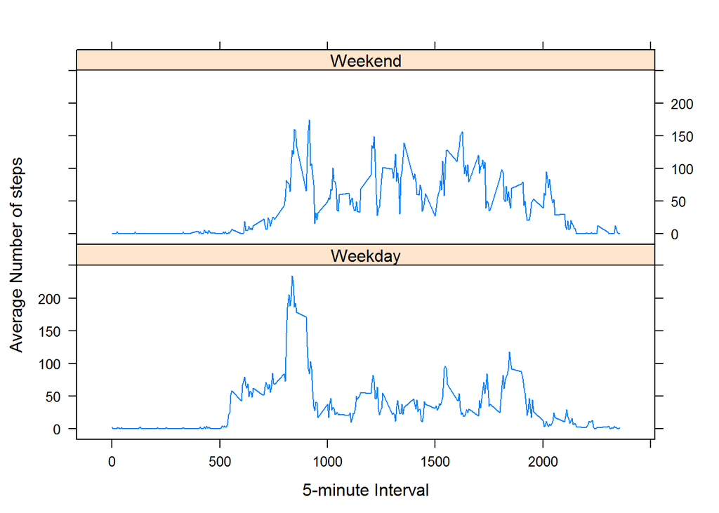

```r
stepsByDay <- aggregate(steps ~ interval + daylevel, data = ActivityData, mean)
names(stepsByDay) <- c("interval", "daylevel", "steps")

library("lattice")
xyplot(steps ~ interval | daylevel, stepsByDay, type = "l", layout = c(1, 2), xlab = "5-minute Interval", ylab = "Average Number of steps")
```

#### There is a higher peak earlier on weekdays and higher overall activity during weekends.